# 클라우드 네이티브 기말 대체 프로젝트 보고서

## 컴퓨터공학과 201935282 송우석

## 목차

0. 프로젝트 자료

- 0-1. 유튜브 시연 영상
- 0-2. API 명세서
- 0-3. ERD

1. 프로젝트 소개

- 1-1. 파트별 소개
- 1-2. 플로우 차트
- 1-3. 통신 절차

2.프론트

- 2-1. React 어플리케이션 구조
- 2-2. 네이밍 규칙
- 2-3. 패키지 구조
- 2-4. api
  - 2-4-1. client.js
  - 2-4-2. AuthAPI.js
  - 2-4-3. AccountAPI.js
- 2-5. components
  - 2-5-1. Account.js
  - 2-5-2. AccountList.js
  - 2-5-3. AuthButton.js
  - 2-5-4. AuthInput.js
  - 2-5-5. MainHeader.js
- 2-6. pages
  - 2-6-1. LoginPage
  - 2-6-2. SignupPage
  - 2-6-3. MainPage.js
  - 2-6-4. DepositPage

3.백엔드

- 3-1. SpringBoot 어플리케이션 구조
- 3-2. 네이밍 규칙
- 3-3. 패키지 구조
- 3-4. 예외 처리
  - 3-4-1. ApiResponse
  - 3-4-2. BaseErrorExcpetion
  - 3-4-3. ErrorMessage
  - 3-4-4. GlobalExceptionHandler
- 3-5. Controller
- 3-6. Service
- 3-7. Repository
- 3-8. Entity
- 3-9. Dto
- 3-10. Spring Security
  - 3-10-1. Spring Security가 없을 경우
  - 3-10-2. Spring Security가 있을 경우
  - 3-10-3. Spring Security 의존성을 사용하는 이유
  - 3-10-4. LoginFilter
  - 3-10-5. SessionFilter
- 3-11. Spring CORS 설정

4. 세션

- 4-1. 세션 동작 원리
- 4-2. 로그인 시 Redis에 저장되는 세션 확인하기

5. 도커 허브 접속 주소와 설치 방법

- 5-1. paytoy.env 파일 작성
- 5-2. 도커 이미지 pull 및 실행
- 5-3. 도커 컴포즈

6. 소감

# 0. 프로젝트 시연 영상

목차

## 0-1. 유튜브 시연 영상

목차

- 시연 영상 [유튜브 링크](https://www.youtube.com/watch?v=8FUW7fRoVbw) 입니다.
  - https://www.youtube.com/watch?v=8FUW7fRoVbw

## 0-2. API 명세서

목차

- [백엔드 API 명세서](https://educated-eggplant-a88.notion.site/API-143285e46d6880ef9032ed8ceeb181d6?pvs=74)
  - https://educated-eggplant-a88.notion.site/API-143285e46d6880ef9032ed8ceeb181d6?pvs=74

## 0-3. ERD

목차

- 백엔드 ERD

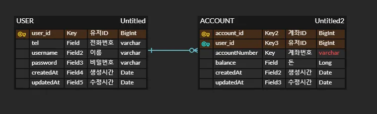

# 1.프로젝트 소개

목차

- 간단한 계좌 입금, 출금, 송금 어플리케이션
- 지불 + 장난감의 의미 PayToy

## 1-1. 파트별 소개

목차

각 파트별 자세한 설명은 파트별 목차에 서술합니다.

### 프론트

- React를 사용합니다.
- Axios를 통해 백엔드와 비동기 통신합니다.
- 본래, 백엔드 취업에 뜻이 있어, 프론트 관련 설명은 미약할 수 있습니다.

### 백엔드

- Spring Boot를 사용합니다.
- 주요 Dependency는 Spring Data JPA와 Spring Security입니다.
- **Spring Data JPA**
  - JPA는 ORM 도구로서 객체와 데이터베이스의 패러다임 불일치를 해결합니다.
  - 객체는 참조로 대상을 가리킵니다. (양방향)
  - 데이터베이스는 FK로 대상을 가리킵니다. (단방향)
  - 이 둘 사이의 패러다임 불일치를 JPA가 해결해줍니다.
- **Spring Security**
  - Spring Security는 인증과 인가 기능을 제공하는 프레임 워크입니다.
  - 본 어플리케이션에서는 로그인에 대해서 CustomLoginFilter를 사용해 인증된 사용자인지 검증합니다.
  - 요청에 대해 여러 검증을 수행하는 Filter는 서블릿과 Controller 사이에 위치합니다.
  - 따라서 Controller로 요청이 도달하기 전 인증된 사용자 인지 검증할 수 있습니다.
  - 추가로 회원가입, 로그인 페이지는 인증하지 않은 사용자(비로그인)도 볼 수 있어야 하므로 일부 요청은 검증을 Pass할 수 있습니다.

### 데이터베이스

- MySQL을 사용합니다.
- 간단한 웹 어플리케이션이므로, User와 Account 테이블을 사용합니다.

## 1-2. 플로우 차트

목차

draw.io 사용

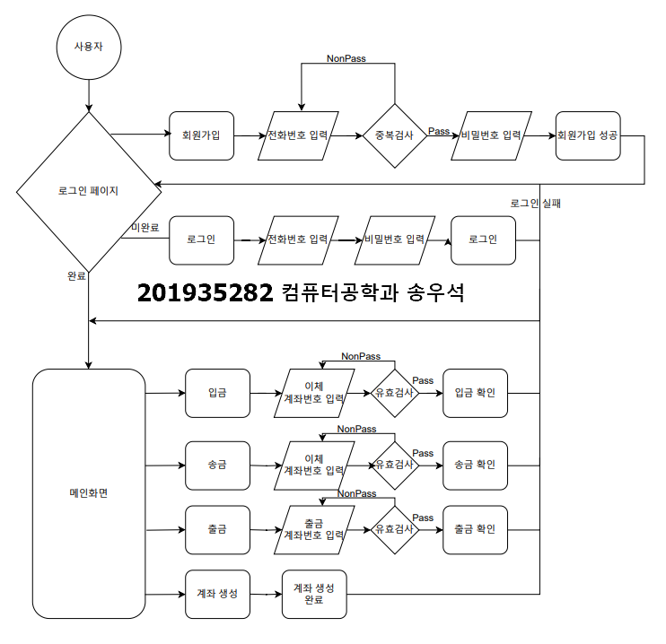

## 1-3. 통신 절차

목차

- React: 프론트 어플리케이션
- Nignx: 로드밸런서
- SpringBoot: 백엔드 어플리케이션
  - 서버 분산을 위해 같은 Spring 도커를 두개 운영하고 Nginx로 로드밸런싱
- Redis: 세션 저장소
- MySQL: 데이터베이스 저장소

[figure not shown]

# 2.프론트 React

목차

자세한 내용은 [PayToy-FE 깃허브 레포지토리](https://github.com/koreaioi/paytoy-fe)를 참고해주세요

- 프론트는 React를 사용했습니다.
- React는 컴포넌트 기반 아키텍처를 채택하고 있어 코드의 재사용성과 유지보수성을 높여줍니다.
- `Axios`를 사용하여 API와 HTTP 비동기 통신이 가능하도록 합니다.

따라서 다음과 같이 패키지 구조를 정했습니다.

## 2-1. React 어플리케이션 구조

목차

- React 에서는 Api, Components, Pages의 패키지 구조를 사용합니다.

## 2-2. 네이밍 규칙

목차

**행위** + **대상**을 기준으로 메소드 명을 작성했습니다.

`예시`: `checkTel`, `getUserInformation`

## 2-3. 패키지 구조

목차

어플리케이션 구조를 고려하여 src 파일에 api, components, pages로 패키지 구조를 설정했습니다.

```
// 도메인 형 패키지 구조
└─paytoy-fe
        ├──src
        │     ├──api   // 실제 백엔드에 요청 로직을 보내는 코드
        │     │ ├── AccountAPI.js
        │     │ ├── AuthAPI.js
        │     │ └── client.js
        │     │
        │     │
        │     ├── components // 컴포넌트
        │     │       ├── Account
        │     │       ├── AccountList
        │     │       ├── AuthButton
        │     │       ├── AuthInput
        │     │       └── MainHeader
        │     └──pages // 페이지
        │             ├── SignupPage     // 회원가입 페이지
        │             ├── LoginPage      // 로그인 페이지
        │             ├── MainPage       // 메인 페이지
        │             ├── DepositPage    // 입금
        │             ├── WithdrawalPage // 출금
        │             └── RemitaancePage // 송금
        │
        └──global
                ├── config
                └── error
```

## 2-4. api

목차

### 2-4-1. client.js

목차

#### axios

- client.js는 axios 설정과 요청과 응답에 대한 선 후 처리를 다룹니다.
- REACT_APP_SERVER_BASE_URL는 .env 파일에서 환경변수로 주입 받습니다.
- 서로 다른 출처간의 자료 공유가 원활하도록 withCredentials : true 설정을 추가합니다.
- content-type을 application/json으로 설정합니다.

#### 요청을 보낼 때

- 백엔드로 요청을 보낼 때 localStorage에 있는 session_id를 헤더에 저장해 보냅니다.
- 만약 session_id가 만료되어 401 응답 상태가 반환 시 localStorage의 session_id와 user_id를 없애고 다시 로그인 합니다.

```
import axios from "axios";


// axios 설정
const client = axios.create({
  baseURL: process.env.REACT_APP_SERVER_BASE_URL,
  withCredentials : true,
  headers: {"Content-Type": "application/json"},
});

// request intercepter
client.interceptors.request.use(
  (config) => {
    const sessionId = localStorage.getItem('session_id');
    if(sessionId) {
      // 로그인 이후 요청을 보낼 때 sessionId를 헤더에 넣어줘야한다.
      config.headers.Session = sessionId;
    }
    return config;
  },
  (error) => {
    return Promise.reject(error);
  }
)

// response intercepter
client.interceptors.response.use(
  (response) => {
    return response;
  },
  (error) => { // 요청의 응답이 error 인 경우 (만약 401이면 session 에러로 다시 로그인)
    if(error.response && error.response.status === 401) {
      alert('로그아웃 되셨습니다.');
      window.location.href = '/'; // '/'로 리다이렉트
      localStorage.removeItem('session_id');
      localStorage.removeItem('user_id');
    }
    return Promise.reject(error);
  }
);

export default client;
```

### 2-4-2. AuthAPI.js

목차

- async는 Axios 요청에 대해서 비동기로 동작하게 한다.
- 로그인, 회원가입, 전화번호 중복 검사, 유저 조회에 대한 실제 API 요청을 진행한다.
- 요청 경로에 의문이라면 [백엔드 API 명세서](https://educated-eggplant-a88.notion.site/API-143285e46d6880ef9032ed8ceeb181d6?pvs=74)를 참고하시면 됩니다.

```
import client from "./client.js"


// userInfomation을 /login 경로로 백엔드에 요청을 전송
export const userLogin = async (userInformaiton) => {
  try{
    const response = await client.post("/login", userInformaiton);
    return response;
  } catch(error) { // 예외 발생 시
    console.log("로그인 실패", error);
    throw error;
  }
}

// userInformation을 /user (회원가입) 경로로 백엔드에 전송
export const userSignup = async (userInformaiton) => {
  try{
    const response = await client.post("/user", userInformaiton);
    return response.data;
  } catch (error) { // 예외 발생 시
    console.log("회원가입 실패", error);
    throw error;
  }
}

// 회원 가입 시 사용하는 전화번호 중복 검사 버튼
export const checkTel = async (tel) => {
  try {
    const response = await client.get(`/user/tel/${tel}`);
    return response.data;
  } catch(error) {
    console.log("중복 검사 실패", error);
    throw error;
  }
}

// userId로 유저 정보를 조회해온다.
export const getUserInformation = async (userId) => {
  try {
    const response = await client.get(`/user/${userId}`);
    return response.data;
  }
  catch(error) {
    console.log("유저 정보를 가져오는데 실패했습니다.", error);
    throw error;
  }
}
```

### 2-4-3 AccountAPI.js

목차

- async는 Axios 요청에 대해서 비동기로 동작하게 한다.
- 계좌 관련 API 요청을 다룹니다.
  - 계좌 생성, 출금, 입금, 송금, 조회
  - get, post, patch 요청 메서드를 사용합니다.
- 요청 경로에 의문이라면 [백엔드 API 명세서](https://educated-eggplant-a88.notion.site/API-143285e46d6880ef9032ed8ceeb181d6?pvs=74)를 참고하시면 됩니다.

```
import client from "./client.js"

// userId로 User의 계좌를 조회합니다.

export const createAccount = async (userId) => {
  try {
    const response = await client.post("/account", userId);
    return response.data;
  } catch(error) {
    console.log("계좌 생성 실패", error);
    throw error;
  }
}

// request 요청 형식에 맞추고 해당 계좌에 입금합니다.
export const depositAccount = async (balanceInfo) => {
  try{
    const response = await client.patch("/account/deposit", balanceInfo);
    return response.data;
  } catch(error) {
    console.log("입금 실패", error);
    throw error;
  }
}

// request 요청 형식에 맞추고 해당 계좌에서 출금합니다.
export const withdrawalAccount = async (balanceInfo) => {
  try{
    const response = await client.patch("/account/withdraw", balanceInfo);
    return response.data;
  } catch(error) {
    console.log("출금 실패", error);
    throw error;
  }
}
// request 요청 형식에 맞추고 계좌간 송금합니다.
export const remittanceAccount = async (balanceInfo) => {
  try{
    const response = await client.patch("/account/transfer", balanceInfo);
    return response.data;
  } catch(error) {
    console.log("송금 실패", error);
    throw error;
  }
}

// 계좌 정보를 조회합니다.
export const getAccountInformation = async (accountNumber) => {
  try {
    const response = await client.get(`/account/${accountNumber}`);
    return response.data;
  } catch(error) {
    console.log("계좌 정보 조회 실패", error);
    throw error;
  }
}
```

## 2-5. components

목차

### 2-5-1. Account.js

목차

- Account라는 이름의 계좌 관련 UI를 처리하는 구성 요소입니다
- 각 버튼 클릭 시 다른 페이지로 라우팅되어 해당 기능을 처리하도록 설계
- style.js 는 생략합니다.

```
import { useNavigate } from "react-router-dom"; // 라우팅 제어 도구
import { AccountNumber, AccountBalance, Button, ButtonWrapper, Wrapper } from "./style.js"


// 각 계좌 관련 요청 별 라우팅 설정
const Account = ({id, accountNumber, balance}) => {

  const navigate = useNavigate();

  const formatBalance = (balance) => {
    console.log(balance);
    return Number(balance).toLocaleString();
  }
  // 송금
  // /remittance/:id로 이동하며 해당 계좌의 accountNumber와 balance를 상태로 전달합니다.
  const handleRemittance = () => {
    navigate(`/remittance/${id}`, {state : {accountNumber, balance}});
  }

  // 입금
  // /deposit/:id로 이동하며 해당 계좌의 accountNumber와 balance를 상태로 전달합니다.
  const handleDeposit = () => {
    navigate(`/deposit/${id}`, {state : {accountNumber, balance}});
  }

  // 출금
  // /withdrawal/:id로 이동하며 해당 계좌의 accountNumber와 balance를 상태로 전달합니다.
  const handleWithdrawal = () => {
    navigate(`/withdrawal/${id}`, {state: {accountNumber, balance}});
  }

  return (
    <Wrapper>
      <AccountNumber>계좌번호 : {accountNumber}</AccountNumber>
      <AccountBalance>{formatBalance(balance)} 원</AccountBalance>
      <ButtonWrapper>
        <Button onClick={handleDeposit}>입금하기</Button>
        <Button onClick={handleRemittance}>송금하기</Button>
        <Button onClick={handleWithdrawal}>출금하기</Button>
      </ButtonWrapper>
    </Wrapper>
  )
}

export default Account;
```

### 2-5-2. AccountList.js

목차

- 사용자 계좌 정보를 백엔드에서 가져와서 화면에 계좌 리스트를 표시하는 역할입니다.
- 각 계좌 객체에 대해 map() 함수를 사용하여 Account 컴포넌트를 렌더링 (return)
- Style.js는 생략한다.

```
const AccountList = () => {
  const [accountData, setAccountData] = useState([]); // accountData 상태를 갱신
  useEffect(() => {
    const loadAccountData = async () => {
      try {
        // user_id는 로그인하면 백엔드에서 응답해주고 이를 localStorage에 저장
        const userId = localStorage.getItem('user_id');//localStorage에서 userId를 가져다 쓴다.
        const data = await getUserInformation(userId); // userId로 유저 정보를 조회 -> 반환 데이터는 data에 저장
        console.log(data.data.accounts);
        setAccountData(data.data.accounts);
      } catch (error) {
        console.log("계좌 정보를 불러오는데 실패했습니다.", error);
      }
    }
    loadAccountData()
  }, []);

  // 각 계좌 객체에 대해 map() 함수를 사용하여 Account 컴포넌트를 렌더링
  return (
    <Wrapper>
      {accountData.map((account => <Account key={account.id} {...account} />))}
    </Wrapper>
  )
}

export default AccountList;
```

### 2-5-3. AuthButton.js

목차

- 버튼을 렌더링한다.
- 버튼이 클릭되었을 때 전달된 onClick 함수가 실행되도록 한다.
- style.js 생략한다.

```
// 이 컴포넌트는 버튼을 렌더링
//  버튼이 클릭되었을 때 전달된 onClick 함수가 실행되도록 한다.
const AuthButton = ({title, onClick}) => {
    return (
      <Wrapepr>
        <Button onClick={() => onClick()} >{title}</Button>
      </Wrapepr>
    )
}

export default AuthButton;
```

### 2-5-4. AuthInput.js

목차

- AuthInput 컴포넌트는 입력 필드를 생성한다.
- 부모 컴포넌트로부터 전달된 데이터로 입력 필드의 동작과 스타일을 설정한다.

```
// AuthInput 컴포넌트는 입력 필드를 생성한다.
// 부모 컴포넌트로부터 전달된 데이터로 입력 필드의 동작과 스타일을 설정한다.
const AuthInput = ({name, placeholder, type, value, onChange}) => {
  return (
    <InputWrapper>
      <Type>{name}</Type>
      <Input
        name = {name}               // 필드의 이름
        placeholder = {placeholder} // 비어있을 경우 값
        type = {type}               // 필드의 타입을 정의
        value = {value}             // 입력 필드의 값
        onChange={onChange}         // 입력값 변경 시 호출되는 함수
        required
      />
    </InputWrapper>
  )
}

export default AuthInput;
```

### 2-5-5. MainHeader.js

목차

- 웹 애플리케이션의 헤더 역할이다.
- 정의한 컴포넌트를 재사용한다.
- style.js 생략

```
const MainHeader = () => {
  const navigate = useNavigate();
  const handleCreateAccount = async () => {
    // user_id를 localStorage에서 가져오고, 이를 API 호출에 사용
    try {
      const userId = localStorage.getItem('user_id');
      const response = await createAccount({userId : userId});
      console.log(response);
      navigate(0);
    } catch (error) {
      console.log("계좌 생성 에러", error);
    }
  }
  // 컴포넌트들을 재사용
  return (
    <Wrapper>
      <Title>PayToy</Title>
      <AccountButton onClick={handleCreateAccount}>계좌 생성</AccountButton>
    </Wrapper>
  )
}

export default MainHeader;
```

## 2-6. pages

목차

- DepositPage, RemittancePage, WithdrawalPage는 각각 입금, 송금, 출금으로 호출하는 요청만 다르므로 DepositPage만 다루겠습니다.

### 2-6-1. LoginPage

목차

- 전화번호와 비밀번호를 백엔드에 전송하여 로그인하는 페이지
- 로그인 성공 시 백엔드에서는 사용자 인증 여부를 확인하기 위해 Session Key를 발급하여 사용자에게 반환한다.
- style.js는 생략한다.

```
const LoginPage = () => {
  const [tel, setTel] = useState("");
  const [password, setPassword] = useState("");
  const navigate = useNavigate();
  // 입력값 변화를 감지하는 이벤트 함수
  const handleData = (e) => {
    if (e.target.name === "tel") {
      setTel(e.target.value);
    }
    if (e.target.name === "password") {
      setPassword(e.target.value);
    }
  }

  const handleSubmit = async () => {
    try {
      // 로그인을 위해 tel, password를 axios 요청 전송
      const response = await userLogin({tel, password});
      if (response.status === 201) {
        const sessionId = response.headers['session'];
        const userId = response.data.data.userId;
        if(sessionId){
          // 로그인 성공 시 백엔드에서 받은 sesion_id 값을 localStorage에 저장
          localStorage.setItem('session_id', sessionId);
        }
        if(userId) {
          // 로그인 성공 시 백엔드에서 받은 userId 값을 localStorage에 저장
          localStorage.setItem('user_id', userId);
        }
        alert("로그인 성공");
        navigate('/main'); // main 화면으로 이동
      } else {
        alert("로그인 실패");
      }
    } catch (error) {
      alert("로그인 중 오류 발생");
      console.log(error);
    }
  }

  // 컴포넌트를 재사용하여 렌더링
  return (
    <Wrapper>
      <Title>PayToy</Title>
      <AuthInput
        name="tel"
        placeholder="tel"
        type="tel"
        value={tel}
        onChange={handleData}
        required
      />
      <AuthInput
        name="password"
        placeholder="password"
        type="password"
        value={password}
        onChange={handleData}
        required
      />
      <AuthButton title = "로그인" onClick={handleSubmit}/>
      <Link to={"/signup"}>회원가입</Link>

    </Wrapper>
  )
}

export default LoginPage;
```

### 2-6-2. SignupPage

목차

- 회원가입을 진행하는 페이지다.
- 전화번호 중복 여부를 확인하고 회원가입 버튼을 누를 수 있다.
- style.js는 생략한다.

```
import { useState } from "react";
import AuthInput from "../../components/AuthInput/AuthInput.js";
import { CheckDuplicate, Title } from "./style.js";
import { Wrapper } from "../LoginPage/style.js";
import { Link, useNavigate } from "react-router-dom";
import AuthButton from "../../components/AuthButton/AuthButton.js";
import { validateUser } from "../../utils/validator.js";
import { checkTel, userSignup } from "../../api/AuthAPI.js";

const SignupPage = () => {
  const navigate = useNavigate();
  const [isTelChecked, setIsTelChecked] = useState(false);
  // formData 세팅
  const [formData, setFormData] = useState({
    username: '',
    tel: '',
    password: '',
    passwordConfirm: '',
  })

  // 입력 값을 formData에 넣어주는 과정
  const handleData = (e) => {
    const {name, value} = e.target

    setFormData({
      ...formData,
      [name] : value,
    });

    if(name === 'tel'){
      setIsTelChecked(false); // 전화번호가 변경되면 중복 검사 초기화
    }
  }

  const handleSubmit = async () => {
    const error = validateUser(formData);
    // 전화번호 중복 검사를 해야 회원가입 버튼을 누를 수 있다.
    if(Object.keys(error).length > 0){
      alert(Object.values(error).join('\n'));
    } else if (!isTelChecked) {
      alert("전화번호 중복 검사를 완료해 주세요.");
    } else {
      try {
        const response = await userSignup(formData);
        if (response) {
          alert("회원가입 성공!");
          navigate('/');
        }
      } catch (error) {
        console.log("회원가입 실패했습니다.", error);
        alert("회원가입 실패.");
      }

    }
  }

  // 전화번호 유효 검사 관련 예외 검증 로직
  const handleDuplicateCheck = async () => {
    const {tel} = formData;
    if(!tel) {
      alert("전화번호를 입력해 주세요");
      return;
    }
    try {
      const response = await checkTel(tel);
      if(response.message === "전화번호가 중복됩니다.") {
        setIsTelChecked(false);
        alert("사용 불가능한 번호입니다.")
      } else {
        setIsTelChecked(true);
        alert("사용가능한 번호입니다.");
      }
    } catch (error) {
      console.log("중복 검사 실패", error);
    }
  }

  // 컴포넌트를 재사용하여 렌더링
  return (
    <Wrapper>
      <Title>PayToy</Title>
      <AuthInput
        name="username"
        placeholder="name"
        type="text"
        value={formData.username}
        onChange={handleData}
      />
      <AuthInput
        name="tel"
        placeholder="tel"
        type="tel"
        value={formData.tel}
        onChange={handleData}
      />
      <CheckDuplicate onClick={handleDuplicateCheck}>중복검사</CheckDuplicate>
      <AuthInput
        name="password"
        placeholder="At least 6 characters"
        type="password"
        value={formData.password}
        onChange={handleData}
      />
      <AuthInput
        name="passwordConfirm"
        placeholder="Re-enter password"
        type="Password"
        value={formData.passwordConfirm}
        onChange={handleData}
      />
      <AuthButton title="회원가입" onClick={handleSubmit}/>
      <Link to={"/"}>로그인</Link>
    </Wrapper>


  )
}

export default SignupPage;
```

### 2-6-3. MainPage.js

목차

```
// 어플리케이션의 헤더
// 로그인한 사용자의 계좌 리스트 컴포넌트를 렌더링
const MainPage = () => {
  return (
    <Wrapper>
      <MainHeader />
      <AccountList />
    </Wrapper>
  )
}

export default MainPage;
```

### 2-6-4. DepositPage

목차

- 값을 입력한다.
- 버튼을 누르면 관련 API 요청을 보낸다.
- 송금, 출금은 API 요청 경로만 다를 뿐이다.
- style.js

```
const DepositPage = () => {
  //const params = useParams(); // account_id 추출 시 사용 params.id
  const navigate = useNavigate();
  const location = useLocation();
  const {accountNumber, balance} = location.state || {};
  const [depositBalance, setDepositBalance] = useState("");

  // 입력값을 반영
  const handleData = (e) => {
    if (e.target.name === "balance") {
      setDepositBalance(e.target.value);
    }
  };

  // 버튼을 누르면 시작되는 함수
  const onSubmit = async () => {
    try {
      const balaceInfo = {
        accountNumber : accountNumber, // 입금 계좌번호
        balance : depositBalance,      // 금액
      }
      // 백엔드로 입금할 계좌와 금액을 포함하여 전송
      const response = await depositAccount(balaceInfo);
      console.log(response);
      alert("입금되었습니다.");
      navigate('/main');
    } catch (error) {
      console.log("입금 실패했습니다.", error);
    }
  }

  const moveToMain = () => {
    navigate('/main');
  }

  // 컴포넌트를 재사용하여 렌더링
  return (
    <Wrapper>
      <HeaderWrapper>
        <Title>PayToy</Title>
      </HeaderWrapper>
      <BoardWrapper>
        <AccountNumber>계좌 번호 : {accountNumber}</AccountNumber>
        <AccountBalance>잔액 : {balance}</AccountBalance>
        <InputWrapper>
          <Input
            name="balance"
            placeholder="입금금액"
            type="text"
            value={depositBalance} // 입금할 금액 입력
            onChange={handleData}
          />
        </InputWrapper>
        <ButtonWrapper>
          <Button onClick={onSubmit}>입금하기</Button>
          <Button onClick={moveToMain}>취소하기</Button>
        </ButtonWrapper>
      </BoardWrapper>
    </Wrapper>
  )
}

export default DepositPage;
```

# 3.백엔드 SpringBoot

목차

Account 엔티티 위주로 설명합니다.

자세한 내용은 [PayToy-BE 깃허브 레포지토리](https://github.com/koreaioi/paytoy-be)를 참고해주세요

## 3-1. Spring Boot 어플리케이션 계층 구조

목차

- 본 어플리케이션에서는 Controller <-> Service <-> Repository 계층 구조를 사용합니다.

## 3-2. 네이밍 규칙

목차

1. Controller와 Service  
   Controller와 Service 단에서는 **행위** + **대상** 을 기준으로 메소드 명을 작성했습니다.

`예시`: `registerUser()`, `saveUser()`

1. Dto  
   Dto는 **"대상"** + **"행위"** + **"Resquest"** or **"Response"** + **"DTO"** 로 클래스명을 작성했습니다.

`예시`: `UserRegisterRequestDto`, `AccountTranferRequestDto`

1. Exception  
   예외 처리는 GlobalExceptionHandler를 구현하여, 백엔드 어플리케이션에서 일어나는 모든 예외를 해당 클래스에서 처리하도록 구현했습니다.

이때 각 예외에 대한 status와 message를 enum 타입으로 정의했습니다.  
이때 enum명은 **"대상"** + **"예외 행위"** 로 작성합니다.

`예시`: `USER_NOT_FOUND`, `ACCOUNT_BALANCE_LACK`

## 3-3. 패키지 구조

목차  
도메인 단위의 유지 보수에 효율적인 도메인 패키지 구조를 택합니다.

```
// 도메인 형 패키지 구조
└─paytoy
        ├──domain
        │     ├──User // User 도메인
        │     │ ├── controller
        │     │ ├── service
        │     │ ├── repository
        │     │ ├── entity
        │     │ ├── exception
        │     │ └── dto
        │     │
        │     │
        │     └── Account // Account 도메인
        │              ├── controller
        │              ├── service
        │              ├── repository
        │              ├── entity
        │              ├── exception
        │              └── dto
        │
        └──global
                ├── config // security, web 관련 설정
                └── error
```

## 3-4. 예외 처리

목차

1. ApiResponse
2. BaseErrorException
3. BaseErrorMessage
4. GlobalExceptionHandler

### 3-4-1. ApiResponse

목차

ApiResponse 클래스는 모든 응답을 형식화 하기 위한 도구로 사용합니다.

- 요청에 대한 성공적인 응답으로 ApiResponse.sucess()를 사용합니다.
- 요청에 대한 실패 응답으로 ApiResponse.fail()을 사용합니다.
  - ApiResponse.fail()을 GlobalExceptionHandler에서 사용합니다.

```
@Getter
@NoArgsConstructor
@AllArgsConstructor
public class ApiResponse<T> {

    private int status;
    private String code;
    private String message;
    private T data;

    // code를 커스텀 할 수 있는 경우 (Custom 예외)
    public static <T> ApiResponse<T> fail(int status, String code, String message) {
        return new ApiResponse<>(status, code, message,null);
    }

    // Java 기본 예외를 처리할 때 사용
    public static <T> ApiResponse<T> fail(int status, String message) {
        return new ApiResponse<>(status, null, message,null);
    }

    // 반환하는 data X, 반환 message O
    public static <T> ApiResponse<T> success(int status,String code, String message) {
        return new ApiResponse<>(status, code, message,null);
    }

    // 반환하는 data O, 반환 message O
    public static <T> ApiResponse<T> success(int status,String code, String message, T data) {
        return new ApiResponse<>(status, code, message,data);
    }

}
```

### 3-4-2. BaseErrorException

목차

각 상황에 맞는 커스텀 에러가 상속할 BaseErrorException을 구현합니다.

모든 커스텀 에러는 BaseErrorException을 상속해야, GlobalExceptionHandler에서 캐치되어 예외가 처리됩니다.

- Status는 에러 상태를 나타냅니다. `ex`: `400`, `401`, `500`
- Code는 유지 보수가 용이하도록 각 에러에 코드를 표시합니다.  
  **"도메인 앞글자""** + **"에러상태"** + **"순서"**  
  실제 예시는 다음 목차 UserErrorMessage에서 확인할 수 있습니다.
- 에러 메세지는 조상 클래스 생성자에 인자로 넣어줍니다.

```
@Getter
public class BaseErrorException extends RuntimeException {

    private final int ErrorStatus;
    private final String ErrorCode;

    public BaseErrorException(int errorStatus, String errorCode, String errorMessage) {
        super(errorMessage);
        ErrorStatus = errorStatus;
        ErrorCode = errorCode;
    }
}
```

### 3-4-3. ErrorMessage

목차

각 도메인 마다 ErrorMessage를 구현합니다.

- `USER_NOT_FOUND.getStatus()`, `USER_NOT_FOUND.getCode()`
- 와 같이 enum 타입에 저장된 값을 꺼내어 사용합니다.

`예시`

```
@Getter             // Getter를 만들어주는 어노테이션
@AllArgsConstructor // 모든 필드가 포함된 생성자를 만들어주는 어노테이션
public enum UserErrorMessage {

    USER_NOT_FOUND(400, "U-400-1", "해당되는 유저가 없습니다."),
    TEL_DUPLICATED(400,"U-400-2", "전화번호가 중복됩니다.");

    final int status;
    final String code;
    final String message;
}
```

### 3-4-4. GlobalExceptionHandler

목차

GlobalExceptionHandler는 어플리케이션 전역에서 throw된 예외를 catch하여 정의된 handle 메서드에 의해서 처리됩니다.

[figure not shown]

[GlobalExceptionHandler 참고 레퍼런스 URL](https://adjh54.tistory.com/79#google_vignette)

```
@Slf4j
@RestControllerAdvice
public class GlobalExceptionHandler {

    // 로그 형식
    private static final String LOG_FORMAT = "Class : {}, Code : {}, Message : {}";

    // 사용자 정의 예외 처리
    @ExceptionHandler(BaseErrorException.class) // BaseErrorException 관련 예외는 다음 handle 메서드에서 처리한다.
    public ResponseEntity<ApiResponse<Void>> handle(BaseErrorException e) {

        logWarning(e, e.getErrorStatus()); // 서버에서 로그 확인을 위해 사용
        ApiResponse<Void> response = ApiResponse.fail(e.getErrorStatus() ,e.getErrorCode(), e.getMessage());

        return ResponseEntity
                .status(e.getErrorStatus())
                .body(response);
    }

    // 서버에서 콘솔로 로그를 확인하기 위해서 사용
    private void logWarning(Exception e, int errorCode) {
        log.warn(e.getMessage(), e);  // 전체 로그 출력, 운영 단계에서는 삭제
        log.warn(LOG_FORMAT, e.getClass().getSimpleName(), errorCode, e.getMessage());
    }

    //@ExceptionHandler(Exception.class) 이하의 코드는 생략

}
```

**실제 반환되는 예외처리 응답 예시 (PostMan)**

[output not shown]

## 3-5. Controller

목차

User와 Account 두가지 엔티티가 있습니다.

설명이 장황해 질 것을 염려하여 Account 도메인 위주 예시를 사용합니다.

- accountService를 의존성 주입 받습니다.
- AccountResponseDto.from()는 서비스단에서 반환받은 객체를 Dto로 변환시켜주는 정적 메서드입니다.
  - Dto가 많고 복잡해지면 Dto <-> Entity 간의 변환보다는 Dto <-> Mapper <-> Entity로 변환하는게 더 좋습니다.
- 공통 응답 형식인 ApiResponse를 사용합니다.
  - `<T>` 는 제네릭으로 컴파일 시점에 클래스 타입이 정해지지 않아, 유동적으로 반환되는 Dto를 정할 수 있습니다.

```
@Slf4j                       // 로그 어노테이션
@RestController              // Restful API
@RequestMapping("/account")  // 기본 경로를 /account 로 설정합니다.
@RequiredArgsConstructor     // private final 된 객체를 의존성 주입해줍니다.
public class AccountController {

    private final AccountService accountService;

    @PostMapping
    public ApiResponse<AccountResponseDto> registerAccount(@RequestBody AccountRegisterRequestDto requestDto) {
        // 서비스 호출 후 반환 값을 AccountResponseDto로 만든다.
        AccountResponseDto response = AccountResponseDto.from(accountService.saveAccount(requestDto));
        return ApiResponse.success(  // 공통 응답 형식 ApiResponse
                ACCOUNT_REGISTER_SUCCESS.getStatus(),
                ACCOUNT_REGISTER_SUCCESS.getCode(),
                ACCOUNT_REGISTER_SUCCESS.getMessage(),
                response            // Dto를 T data에 넣어준다.
        );
    }

    /*
    * 입금과 출금 Controller는 코드가 길어질 까봐 생략합니다.
    * 송금에서 관련 비지니스 로직을 모두 사용합니다!
    */

    @PatchMapping("/transfer")
    public ApiResponse<AccountResponseDto> transferAccount(@RequestBody @Valid AccountTranferRequestDto requstDto) {
        accountService.transferBalance(requstDto);

        return ApiResponse.success(
                ACCOUNT_TRANSFER_SUCCESS.getStatus(),
                ACCOUNT_TRANSFER_SUCCESS.getCode(),
                ACCOUNT_TRANSFER_SUCCESS.getMessage()
        );
    }

    // 계좌번호로 Account 조회 API
    @GetMapping("/{accountNumber}")
    public ApiResponse<AccountResponseDto> getAccount(@PathVariable String accountNumber) {
        AccountResponseDto response
                = AccountResponseDto.from(accountService.findByAccountNumber(accountNumber));

        return ApiResponse.success(  // 공통 응답 형식 ApiResponse
                ACCOUNT_GET_SUCCESS.getStatus(),
                ACCOUNT_GET_SUCCESS.getCode(),
                ACCOUNT_GET_SUCCESS.getMessage(),
                response             // Dto를 T data에 넣어준다.
        );
    }
}
```

## 3-6. Service

목차

AccountService 에서는 실제 Account 관련 비지니스 로직을 처리합니다.

- 도메인 로직
  - 입금, 출금, 송금 모두 Account객체.withdraw() 와 같은 내부 메서드를 사용합니다.
  - 이는 Account 필드의 Balance(잔액) 관련 로직을 Account 필드에 책임을 두기 위함입니다.
- checkAccountNumber()
  - checkAccountNumber는 입금, 출금, 송금에서 자주 사용하므로 리팩토링 합니다.
- @Transactional
  - Transactional는 해당 메서드를 하나의 트랜잭션 안에서 관리하도록 합니다.
  - 데이터의 무결성을 보장합니다.
  - 영속성 컨텍스트에 존재하는 객체가 변동되었는지 체크합니다.
    - 이때 변경되었을 경우 자동으로 변경 사항을 데이터베이스에 반영합니다. (더티 체킹)
  - @Transactional의 남용은 과도한 Lock으로 인해 성능 저하를 일으킬 수 있습니다.

```
@Slf4j
@Service
@RequiredArgsConstructor
public class AccountService {

    private final AccountRepository accountRepository;
    private final UserService userService;

    // 실제 User가 존재하는 지 확인 후 계좌를 생성해줍니다.
    public Account saveAccount(AccountRegisterRequestDto requestDto) {
        User findUser = userService.findUserById(requestDto.userId());
        Account saveAccount = accountRepository.save(Account.from(findUser));
        findUser.getAccounts().add(saveAccount);

        return saveAccount;
    }

    // 입금
    @Transactional // 영속성 컨텍스트 조회 객체 더티 체킹과 무결성 보장
    public Account depositBalance(AccountBalanceRequstDto requestDto) {
        Account findAccount = checkAccountNumber(requestDto.accountNumber());
        findAccount.deposit(requestDto.balance());
        return findAccount;
    }

    // 출금
    @Transactional // 영속성 컨텍스트 조회 객체 더티 체킹과 무결성 보장
    public Account withdrawBalance(AccountBalanceRequstDto requestDto) {
        Account findAccount = checkAccountNumber(requestDto.accountNumber());
        findAccount.withdraw(requestDto.balance());
        return findAccount;
    }

    // 이체 (입금 + 출금)
    @Transactional // 영속성 컨텍스트 조회 객체 더티 체킹과 무결성 보장
    public void transferBalance(AccountTranferRequestDto requestDto) {
        String senderAccNum = requestDto.sendAccountNumber();
        String receiveAccNum = requestDto.receiveAccountNumber();
        Long balance = requestDto.balance();

        // 보내는 이와 받는 이의 계좌를 조회합니다.
        // 만약 계좌가 없다면 CustomAccountNotFoundException를 던집니다.
        Account sendAccount = findByAccountNumber(senderAccNum);
        Account receiveAccount = findByAccountNumber(receiveAccNum);

        // 도메인 로직을 사용해 각 계좌에 입금, 출금을 수행합니다.
        sendAccount.withdraw(balance);
        receiveAccount.deposit(balance);
    }


    public Account findByAccountNumber(String accountNumber) {
        return checkAccountNumber(accountNumber);
    }

    /*
    * 리팩토링
    * */

    // Optional 값이 null인 경우 CustomAccountNotFoundException를 던집니다.
    // AccountNotFoundException은 실제 Java 예외이므로 앞에 Custom을 붙였습니다.
    private Account checkAccountNumber(String accountNumber) {
        return accountRepository.findByAccountNumber(accountNumber)
                .orElseThrow(CustomAccountNotFoundException::new);
    }

}
```

## 3-7. Repository

목차

JpaRepository를 상속하여 손쉽에 데이터베이스에 접근할 수 있습니다.

findByAccountNumber(String accoutNumber)는 계좌번호로 계좌를 조회하는 메소드입니다.

Optional은 null을 포함할 수 있는 클래스 타입으로 조회된 Account가 Null일 경우와 아닐 경우를 나누어 예외처리합니다.

```
public interface AccountRepository extends JpaRepository<Account, Long> {

    //Account 테이블에서 accountnumber로 조회하게 해주는 JPA 메소드
    Optional<Account> findByAccountNumber(String accountNumber);
}
```

## 3-8. Entity

목차

- User와 Account는 일대다 관계입니다.
- Account와 User는 다대일 관계입니다.

Account기준 `다대일`이므로 @ManyToOne과 지연로딩 설정을 사용합니다.

- 참고 User  
  User 엔티티에는 @OneToMany(mappedBy = "user")를 사용합니다.  
  일대다 그리고 연관관계의 주인이 Account라는 의미입니다.

```
@Entity
@Table(name="accounts") // account는 MySQL 예약어 -> 테이블 명을 accounts로 명시
@Getter
@NoArgsConstructor(access = AccessLevel.PROTECTED)
public class Account extends BaseTimeEntity {

    @Id @Column(name="account_id")
    @GeneratedValue
    private Long id;

    private String accountNumber; // 계좌 번호
    private Long balance;         // 잔액

    @JsonIgnore                   // 무한 참조를 방지하기 위함
    @ManyToOne(fetch = FetchType.LAZY)
    @JoinColumn(name="user_id")   // Account에서 사용할 FK키 컬럼 이름
    private User user;           // 계좌 소유주

    // 빌더 패턴 사용 - 코드 가독성 향상
    @Builder
    private Account(User user) {
        this.accountNumber = generateAccountNumber(); // 계좌 번호를 랜덤으로 생성
        balance = 1000L; // 계좌 개설 시 1000원
        this.user = user;
    }

    // User에 대한 계좌를 생성해주는 실제 도메인 로직
    public static Account from(User user) {
        return Account.builder().user(user).build();
    }

    // 계좌 번호 생성 도메인 로직
    private String generateAccountNumber() {
        Random random = new Random();
        StringBuilder accountNumberBuilder = new StringBuilder("1002");

        // 8자리 무작위 숫자 생성
        for (int i = 0; i < 8; i++) {
            accountNumberBuilder.append(random.nextInt(10)); // 0~9 사이 숫자 추가
        }

        return accountNumberBuilder.toString();
    }

    // 입금을 수행하는 도메인 로직
    public void deposit(Long money){
        this.balance += money;
    }

    // 출금을 수행하는 도메인 로직
    public void withdraw(Long money){
        if(balance - money < 0){ // 잔액이 충분한 지 검증 합니다.
            throw new BalanceLackException(); // 잔액이 부족하면 BalanceLackException()을 던집니다.
        }
        this.balance -= money;
    }
}
```

## 3-9. Dto

목차

`Record`: Java 14부터 도입된 Record 클래스는 불변 데이터를 객체 간에 전달하는 작업을 간단하게 만들어줍니다.

- Getter와 생성자가 자동으로 생성됩니다.
- `@NotNull`, `@PositiveOrZero` 와 같은 `@Valid` 어노테이션으로 요청으로 들어오는 값을에 대해 유효성 검사를 진행합니다.
- 예외 발생 시 message 속성에 정의된 메세지가 반환됩니다.

```
public record AccountTranferRequestDto (

        String sendAccountNumber,
        @NotNull(message = "금액을 입력해주세요.")
        @PositiveOrZero(message = "금액은 양수로 입력해주세요.")
        @Digits(integer = 10, fraction = 0, message = "금액은 숫자로 입력해야 하며 소수점을 포함할 수 없습니다")
        Long balance,
        String receiveAccountNumber

){
}
```

## 3-10. Spring Security

목차

스프링 시큐리티의 완벽한 이해보다는, 사용한 이유와 LoginFilter와 SessionFilter의 역할을 이해합니다.

### 3-10-1. Spring Security가 없을 경우

목차

클라이언트의 요청은 서버 컴퓨터의 WAS (톰캣)의 필터들을 통과한 뒤 스프링 컨테이너의 컨트롤러에 도달합니다.

(컨트롤러 앞단에 여러 과정이 존재하지만, 시큐리티를 다루는 과정에서 중요하지 않기 때문에 생략합니다.)

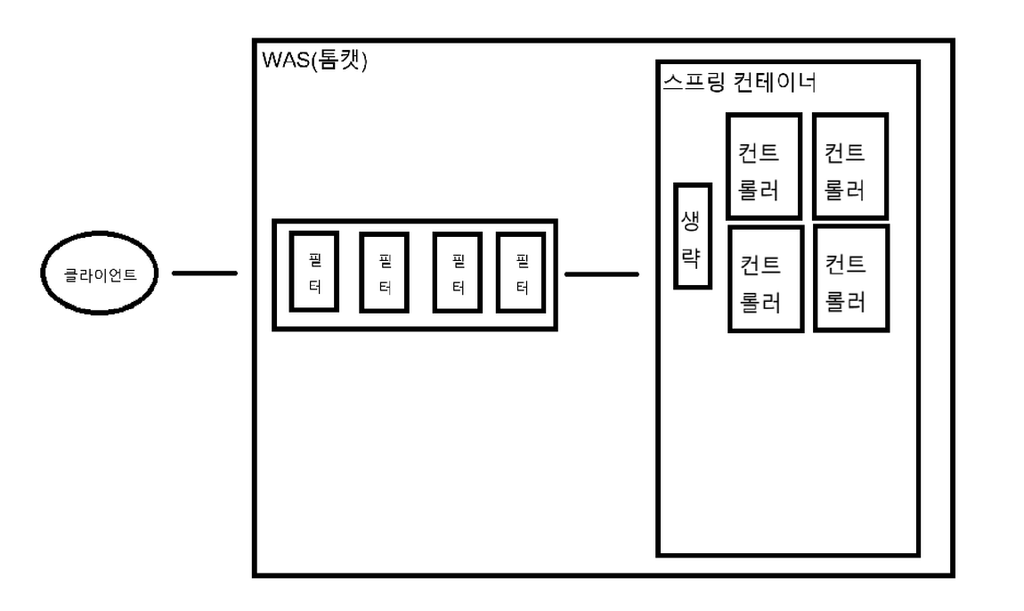

### 3-10-2. Spring Security가 있을 경우

목차

- WAS의 필터에 하나의 필터를 만들어서 넣고 해당 필터에서 요청을 가로챕니다.
- 해당 요청은 스프링 컨테이너 내부에 구현되어 있는 스프링 시큐리티 감시 로직을 거칩니다.
- 시큐리티 로직을 마친 후 다시 WAS의 다음 필터로 복귀

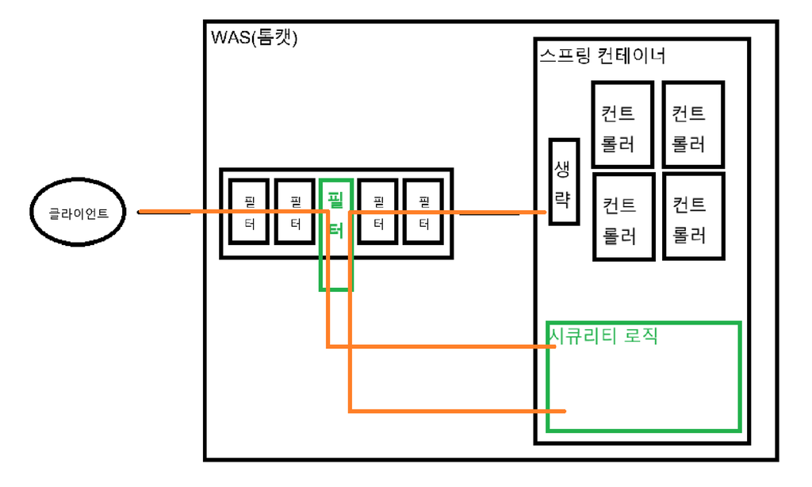

### 3-10-3. Spring Security 의존성을 사용하는 이유

목차

Spring Security를 사용해 LoginFilter와 SessionFilter를 만들어 로그인 과정을 구현하고자합니다. 각 필터의 역할은 다음과 같습니다.

- LoginFilter
  - "/login" 요청에 대해서 로그인을 수행합니다.
  - 유효한 사용자라면 Session을 생성해 Redis에 저장합니다.
  - Session의 key를 사용자의 Header에 심어줍니다.
  - 로그인 이후 모든 요청에 Session Key를 저장하여 백엔드에 요청을 보냅니다.
- SessionFilter
  - 로그인한 사용자가 맞는 지 즉, 사용자를 인증하는 기능을합니다.
  - Request Header에 session_id 값을 꺼내어 Redis에서 유효한 지 확인합니다.
  - 인증된 사용자의 Session이라면 통과합니다.
  - Session이 잘못됐다면 401 에러와 지정한 메세지를 반환합니다.

### 3-10-4. LoginFilter

목차

- UsernamePasswordAuthenticationFilter를 상속한 LoginFilter는 Default로 "/login"에 대해서 동작하게 설계되어있습니다.
- 가장 의문이 드는 코드는

  ```
  authenticationManager.authenticate(new UsernamePasswordAuthenticationToken(tel, password));
  ```

  일 것입니다.
1. 위 코드는 로그인 요청에서 추출한 전화번호와 비밀번호로 인증객체(AuthenticationToken)을 만들고 authenticate 메소드에 넘겨줍니다.
2. 시큐리티는 이 인증객체로 실제 사용자 DB에서 값을 조회해 비교합니다.
3. 실제 사용자 DB와 일치하면 로그인이 성공하고 successfulAuthentication 메서드가 실행됩니다.
   - 사용자 전화번호로 Session을 만듭니다.
   - Session을 Redis에 저장합니다.
   - Session Key를 Response Header에 추가하여 반환합니다.
4. 실제 사용자 DB와 일치하지 않으면 로그인에 실패하고 unsuccessfulAuthentication 메서드가 실행됩니다.
   - 정해진 로그인 실패 메세지를 반환합니다.

```
@Slf4j
public class LoginFilter extends UsernamePasswordAuthenticationFilter {

    private final ObjectMapper objectMapper = new ObjectMapper();
    private final AuthenticationManager authenticationManager;
    private final SessionUtils sessionUtils;
    private final CustomSessionRepository customSessionRepository;

    // 생성자 주입 방식
    public LoginFilter(AuthenticationManager authenticationManager, SessionUtils sessionUtils, CustomSessionRepository customSessionRepository) {
        this.authenticationManager = authenticationManager;
        this.sessionUtils = sessionUtils;
        this.customSessionRepository = customSessionRepository;
    }


    @Override
    public Authentication attemptAuthentication(HttpServletRequest request, HttpServletResponse response) throws AuthenticationException {

        String tel = null;
        String password = null;

        // form-data 또는 json으로 둘 다 처리가 가능
        // JSON 요청 처리
        if (request.getContentType().equals("application/json")) {
            try {
                Map requestMap = objectMapper.readValue(request.getInputStream(), Map.class);
                tel = (String)requestMap.get("tel");
                password = (String)requestMap.get("password");
            } catch (IOException e) {
                e.printStackTrace();
            }
        } else { // form-data 요청 처리
            // 요청이 form-data 형식인경우 obtain으로 바로 꺼낼 수 있다.
            tel = obtainUsername(request);
            password = obtainPassword(request);
        }

        // request에서 추출한 tel과 password로 실제 사용자인 지 검증
        return authenticationManager.authenticate(new UsernamePasswordAuthenticationToken(tel, password));
    }

    // 로그인이 성공하면 실행되는 메서드
    @Override
    protected void successfulAuthentication(HttpServletRequest request, HttpServletResponse response, FilterChain chain, Authentication authentication) throws IOException {
        // 유저 정보
        CustomUserDetails userDetails = (CustomUserDetails) authentication.getPrincipal();
        String tel = userDetails.getTel();

        Session session = sessionUtils.createSessionId(tel);
        sessionUtils.addHeaderSessionId(response,session.getId());
        customSessionRepository.save(session);

        response.setCharacterEncoding("UTF-8");      // 한글 설정
        response.setContentType("application/json"); // 응답을 JSON으로
        response.setStatus(LOGIN_SUCCESS.getStatus());

        response.getWriter().write(new ObjectMapper().writeValueAsString(ApiResponse.success(
                LOGIN_SUCCESS.getStatus(),
                LOGIN_SUCCESS.getCode(),
                LOGIN_SUCCESS.getMessage())));
    }

    // 로그인에 실패하면 실행되는 메서드
    @Override
    protected void unsuccessfulAuthentication(HttpServletRequest request, HttpServletResponse response, AuthenticationException failed) throws IOException, ServletException {
        log.info("unsuccessfulAuthentication 실행");

        response.setStatus(LOGIN_FAIL.getStatus());
        response.setCharacterEncoding("UTF-8");      // 한글 설정
        response.setContentType("application/json"); // 응답을 JSON으로

        response.getWriter().write(new ObjectMapper().writeValueAsString(ApiResponse.success(
                LOGIN_FAIL.getStatus(),
                LOGIN_FAIL.getCode(),
                LOGIN_FAIL.getMessage())));
    }
}
```

### 3-10-5. SessionFilter

목차

SessionFilter는 클라리언트로부터 요청에 대해서 인증된 사용자 인지 검증합니다.

1. 경로가 /login 인 경우는 LoginFilter에서 로직을 수행합니다.
   - filterChain.doFilter(request, response); 를 사용해 다음 필터로 넘깁니다.
2. Request 헤더에서 session_id를 추출하는데 값이 null일 경우, 다음 필터로 넘깁니다.
   - 이때 request에 errormessage를 저장하여, 시큐리티 맨 마지막에서 동작하는 예외처리 로직에 걸리도록합니다..
3. session_id의 값은 있지만 유효하지 않은 경우 (잘못된 session_id, 사용 기간이 지난 session_id), 다음 필터로 넘깁니다.
   - 이때 request에 errormessage를 저장하여, 시큐리티 맨 마지막에서 동작하는 예외처리 로직에 걸리도록합니다.
- 올바른 사용자라면 요청이 시작되고 끝나는 요청 수행 기간동안, 스프링 시큐리티 세션에 잠시 저장합니다.

```
@Slf4j
public class SessionFilter extends OncePerRequestFilter {

    private final static String LOGIN_URL = "/login";
    private final SessionUtils sessionUtils;

    public SessionFilter(SessionUtils sessionUtils) {
        this.sessionUtils = sessionUtils;
    }

    @Override
    protected void doFilterInternal(HttpServletRequest request, HttpServletResponse response, FilterChain filterChain) throws ServletException, IOException {
        log.info("SessionFilter 실행");

        // URL이 /login인 경우 토큰 검증 건너뛰기
        if (request.getRequestURI().equals(LOGIN_URL)) {
            filterChain.doFilter(request, response);
            return;
        }

        // request로부터 sessiond_id를 추출한다.
        String sessionId = request.getHeader("session_id");
        log.info("sessionId: {}", sessionId);

        // 만약 session_id가 null일 경우 다음 필터로 넘긴다.
        if (!sessionUtils.validateSessionId(sessionId, request)) {
             filterChain.doFilter(request, response);
             return;
        }

        // session_id로 Redis에서 올바른 사용자인 지 확인하는 과정
        // findUser가 비어있다면(null) errormessage를 심은 뒤 다음 필터로 넘긴다.
        Optional<User> findUser = sessionUtils.getUsereBySessionId(sessionId);
        if(findUser.isEmpty()){
            request.setAttribute("errormessage", SESSION_ID_INVALID);
            filterChain.doFilter(request, response);
            return;
        }

        // 여기까지 왔다면, 올바른 session_id이다.
        // session_id로 조회한 사용자를 요청기간 동안 유지하기 위해서 SecurityContextHolder라는 스프링 시큐리티 세션에 잠시 저장합니다.
        CustomUserDetails customUserDetails = new CustomUserDetails(findUser.get());
        Authentication authToken = new UsernamePasswordAuthenticationToken(customUserDetails, null, customUserDetails.getAuthorities());
        SecurityContextHolder.getContext().setAuthentication(authToken);

        filterChain.doFilter(request, response);
    }
}
```

## 3-11. Spring CORS 설정

목차

- 다음과 같은 cors 설정을 가지는 Bean을 등록한다.
- SecurityConfig에서 해당 Bean을 사용한다.

```
@Bean
    public CorsConfigurationSource corsConfigurationSource() {
        CorsConfiguration corsConfiguration = new CorsConfiguration();

        // 모든 경로에 대해 CORS 허용
        corsConfiguration.setAllowedOriginPatterns(List.of("*"));
        // CORS 허용 메소드 - preFlight 때문에 OPTIONS도 허용
        corsConfiguration.setAllowedMethods(List.of("GET","PATCH", "POST", "PUT", "DELETE", "HEAD", "OPTIONS"));
        // 허용 헤더
        corsConfiguration.setAllowedHeaders(List.of("Authorization", "Cache-Control", "Content-Type","Session",                                                                      "session_id"));
        // 노출할 헤더
        corsConfiguration.setExposedHeaders(List.of("Session"));
        // 모든 자격 증명 허용
        corsConfiguration.setAllowCredentials(true);

        UrlBasedCorsConfigurationSource source = new UrlBasedCorsConfigurationSource();
        source.registerCorsConfiguration("/**", corsConfiguration);

        return source;
    }
```

```
@Bean
    public SecurityFilterChain filterChain(HttpSecurity http) throws Exception {
        http.cors(httpSecurityCorsConfigurer -> httpSecurityCorsConfigurer.configurationSource(corsConfigurationSource()));

        // 커스텀 필터 추가, 이외 설정 생략

        return http.build();
    }
```

# 4. 세션

목차

세션은 Redis를 사용했습니다.

## 4-1. 세션 동작 원리

목차

1. 유저가 로그인시 세션 key와 value가 생성후 Redis에 저장
   - 세션 key는 UUID를 사용한 랜덤 숫자
   - 세션 value는 유저의 전화번호
2. 로그인 요청이 들어와 사용자 인증이 완료되면, 세션 key를 Response Header에 저장하여 응답합니다.
3. 로그인 이후 모든 요청에는 세션 key를 포함합니다.
4. 백엔드에서는 인증이 필요한 API에서 Request에서 세션 key를 추출합니다.
5. 추출한 세션 key로 Redis에서 조회를 합니다.
   - 유효한 key라면 인증 통과
   - 유효하지 않은 key라면 401 에러를 응답합니다.
6. 세션은 10분간 유효합니다.
- Session Entity를 Redis로 저장할 때 Value의 맨앞에 '0'은 자동으로 삭제되어 저장됩니다.
- 따라서 Value를 사용자의 tel과 비교할 때 0을 붙여서 비교합니다.

## 4-2. 로그인 시 Redis에 저장되는 세션 확인하기

목차

로그인 후 Redis에 접속하여 세션이 잘 저장되는 지 확인합니다.

1. Redis Docker 컨테이너에 접속합니다.

```
docker exec -it paytoy-redis /bin/bash
```

1. Redis에 접속합니다.

```
redis-cli
```

1. 세션 Key를 확인합니다.

   ```
   keys *
   ```

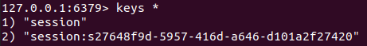

2. 세션 Key를 가지고 세션 Value를 확인합니다.

   ```
   HGETALL session:{key값}
   ```

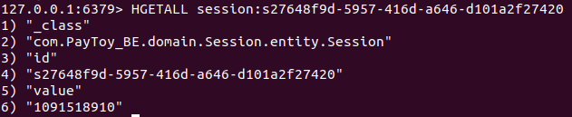

# 5. 도커 허브 접속 주소와 설치 방법

목차

## 5-1. paytoy.env 파일 작성

목차

- Spring Boot Docker 에서 사용할 환경 변수 파일을 작성합니다.

```
DATABASE_URL=jdbc:mysql://paytoy-mysql:3306/paytoy-db
DATABASE_USERNAME=paytoy
DATABASE_PASSWORD=1234

PUBLIC_IP_FRONT=http://localhost:3000/
SPRING_REDIS_HOST=paytoy-redis
SPRING_REDIS_PORT=6379
SPRING_REDIS_PASSWORD=6379
```

## 5-2. 도커 이미지 pull 및 실행

목차

- 위 명령어부터 차례대로 실행하면 됩니다.
- React 컨테이너 실행 시 VM Public IP를 사용합니다.

```
# 네트워크 생성
docker network create paytoy-network

# Redis 컨테이너
docker run -d --name paytoy-redis --network paytoy-network -p 6379:6379 redis

# MySQL 컨테이너
docker run --name paytoy-mysql --network paytoy-network -dit -p 3306:3306 -e MYSQL_ROOT_PASSWORD=1234 -e MYSQL_DATABASE=paytoy-db -e MYSQL_USER=paytoy -e MYSQL_PASSWORD=1234 mysql:8.0 --character-set-server=utf8mb4 --collation-server=utf8mb4_unicode_ci

# Spring 컨테이너 2개
# env 파일 위치에 주의하세요 + env 파일 위치에서 실행
docker run --name paytoy --network paytoy-network  --env-file ./paytoy.env -d -p 8080:8080 {사용자명}/{레포지토리}:{버전}
docker run --name paytoy1 --network paytoy-network  --env-file ./paytoy.env -d -p 8081:8080 {사용자명}/{레포지토리}:{버전}

# nginx 컨테이너 - spring을 먼저 가동 해야함
docker run -dit --name paytoy-nginx --network paytoy-network -p 80:80 {사용자명}/{레포지토리}:{버전}

# 리액트 컨테이너
#docker run -dit -p 3000:3000 --name paytoy-fe --network paytoy-network -e REACT_APP_SERVER_BASE_URL="http://{VM Public IP}:80/" {사용자명}/{레포지토리}:{버전}

docker run -dit -p 3000:3000 --name paytoy-fe --network paytoy-network -e REACT_APP_SERVER_BASE_URL="http://{VM Public IP}:80/" {사용자명}/{레포지토리}:{버전}
```

## 5-3. 도커 컴포즈

목차

위 도커 명령어를 순서대로 실행하기 귀찮다면 다음과 같이 도커 컴포즈 파일을 구성하고 실행하시면 됩니다.

### 주의사항

- 필히 **paytoy.env 파일**을 작성해주세요!
- 프론트 환경변수 **{VM_PUBLIC_IP}는 꼭 자신의 VM에 맞춰서** 수정 후 실행 해주세요!
- 도커 파일 컴포즈 후 Spring 어플리케이션 **첫 실행 시, JDBC 연결 오류가 일어날 수 있습니다.**
  - **docker start paytoy**
  - **docker start paytoy1**
  - 위 명령어로 다시 실행하면 문제 없이 실행 됩니다.

```
version: '3.8'

services:
  redis:
    image: redis
    container_name: paytoy-redis
    networks:
      - paytoy-network
    ports:
      - "6379:6379"

  mysql:
    image: mysql:8.0
    container_name: paytoy-mysql
    networks:
      - paytoy-network
    environment:
      MYSQL_ROOT_PASSWORD: "1234"
      MYSQL_DATABASE: "paytoy-db"
      MYSQL_USER: "paytoy"
      MYSQL_PASSWORD: "1234"
    command: [
      "--character-set-server=utf8mb4",
      "--collation-server=utf8mb4_unicode_ci"
    ]
    ports:
      - "3306:3306"

  spring1:
    image: {사용자명}/{레포지토리}:{버전}
    container_name: paytoy
    networks:
      - paytoy-network
    env_file:
      - ./paytoy.env
    ports:
      - "8080:8080"
    depends_on:
      - redis
      - mysql

  spring2:
    image: {사용자명}/{레포지토리}:{버전}
    container_name: paytoy1
    networks:
      - paytoy-network
    env_file:
      - ./paytoy.env
    ports:
      - "8081:8080"
    depends_on:
      - redis
      - mysql

  nginx:
    image: {사용자명}/{레포지토리}:{버전}
    container_name: paytoy-nginx
    networks:
      - paytoy-network
    ports:
      - "80:80"
    depends_on:
      - spring1
      - spring2

  frontend:
    image: {사용자명}/{레포지토리}:{버전}
    container_name: paytoy-fe
    networks:
      - paytoy-network
    environment:
      REACT_APP_SERVER_BASE_URL: "http://{VM_PUBLIC_IP}/"
    ports:
      - "3000:3000"
    depends_on:
      - nginx

networks:
  paytoy-network:
    driver: bridge
```

# 6. 소감

목차

안녕하세요. 저는 컴퓨터공학과 201935282 송우석입니다.

저는 AWS를 활용하여 맹목적으로 CI/CD를 구축하여 사용했습니다.  
클라우드 네이티브 수업을 들으면서 네트워크 흐름을 정확히 이해할 수 있었습니다.

주마다 반복적으로 까먹지 않게 네트워크 흐름 (특히 포트포워딩)에 대해서 설명해주셔서 까먹지 않고 오래 기억할 수 있었습니다.  
실제 프로젝트에서 docker와 docker compose에 대해서 정확히 이해하고 사용할 수 있게 되었습니다.

멋진 백엔드 개발자가 되도록 노력하겠습니다.

감사합니다.